# So what can r markdown do?

Josh Hanna

September 14, 2016

### Getting started

To play with r markdown, I have downloaded 5 years worth of data on monthly United States Brent Oil Fund prices, Horizons SP/TSX 60 Canadian dollar fund prices, and the conversion of USD to CAD. I will run correlational analyses, and demonstrate the use of *ggplot2* to create some pretty line graphs.

The first step is opening up the libraries we will need. These include *ggplot2*, the grammar of graphics plot, and *apaTables*, a library for the creation of pretty apa correlational, regression, and ANOVA tables created by Guelph’s very own David Stanley.

```r
library(ggplot2)
library(apaTables)
```

The next step is **importing data** into a new data frame

```r
#It is worth noting that using a hashtag before text in script will keep the code from executing.
#also, creating text, followed by a little arrow, and a command will create a new data fram, in this case a whole data set
#but I will also use this command later to build a graph
BNO.HXT.5.year.monthly<-read.csv("BNO HXT 5 year monthly.csv", header=TRUE)
```

And then creating pretty **APA correlation tables** to get an idea of the relationships between our variables. BNO is a United States Brent Crude Oil fund, and HXT is a Canadian large market capitalization stock index. CAD USD is the exchange rate(the price in Canadian Dollars of one American dollar). All are reported in CAD, and prices of the indices are adjusted for stock splits where appropriate.

```r
apa.cor.table(BNO.HXT.5.year.monthly,filename="apacorrelationtable.doc", show.conf.interval=TRUE)
```

```
##
##
## Means, standard deviations, and correlations with confidence intervals
##
##
##   Variable    M     SD    1            2            3
##   1. Date     30.50 17.46
##
##   2. BNO_Open 35.64 10.03 -.67**
##                           [-.79, -.50]
##
##   3. HXT_Open 24.04 3.01  .87**        -.38**
##                           [.79, .92]   [-.58, -.14]
##
##   4. CAD_USD  1.12  0.13  .91**        -.84**       .73**
##                           [.86, .95]   [-.90, -.75] [.59, .83]
##
##
## Note. * indicates p < .05; ** indicates p < .01.
## M and SD are used to represent mean and standard deviation, respectively.
## Values in square brackets indicate the 95% confidence interval for each correlation.
## The confidence interval is a plausible range of population correlations
## that could have caused the sample correlation (Cumming, 2014).
##
```

### Graphing using GGplot2

*GGplot2* functions kind of like a series of transparancies to build a pretty looking graph. Each layer of code adds something to the graph, like labels, new data representations, changes colours, or scales. I will demonstrate how it works with a series of different codes to, hopefully, add some progressively more pretty graphs to this document.First, I am going to create a new data frame I will label ‘Line1’ which is going to serve as the base for the line graph.

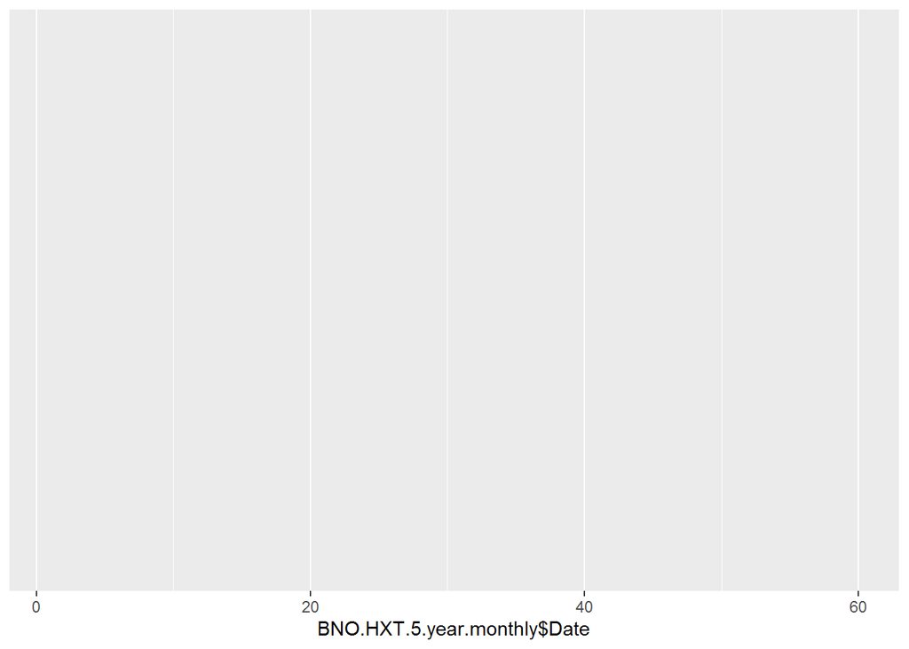

```r
Line1<-ggplot(BNO.HXT.5.year.monthly, aes(BNO.HXT.5.year.monthly$Date))
print(Line1)
```

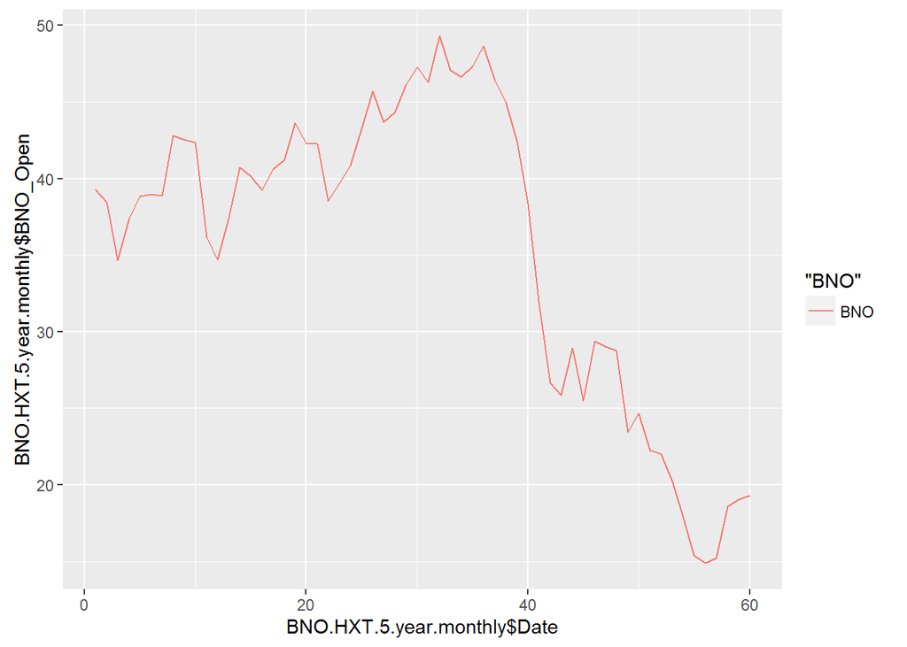

```r
Line1<-Line1+geom_line(aes(y=BNO.HXT.5.year.monthly$BNO_Open, colour="BNO"))
print(Line1)
```

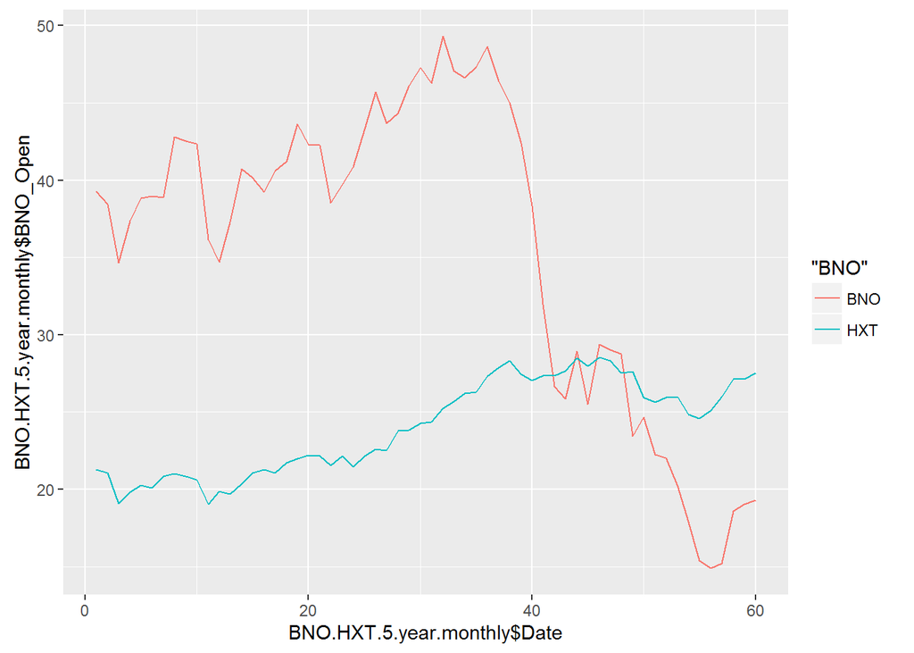

```r
Line1<-Line1+geom_line(aes(y=BNO.HXT.5.year.monthly$HXT_Open, colour="HXT"))
print(Line1)
```

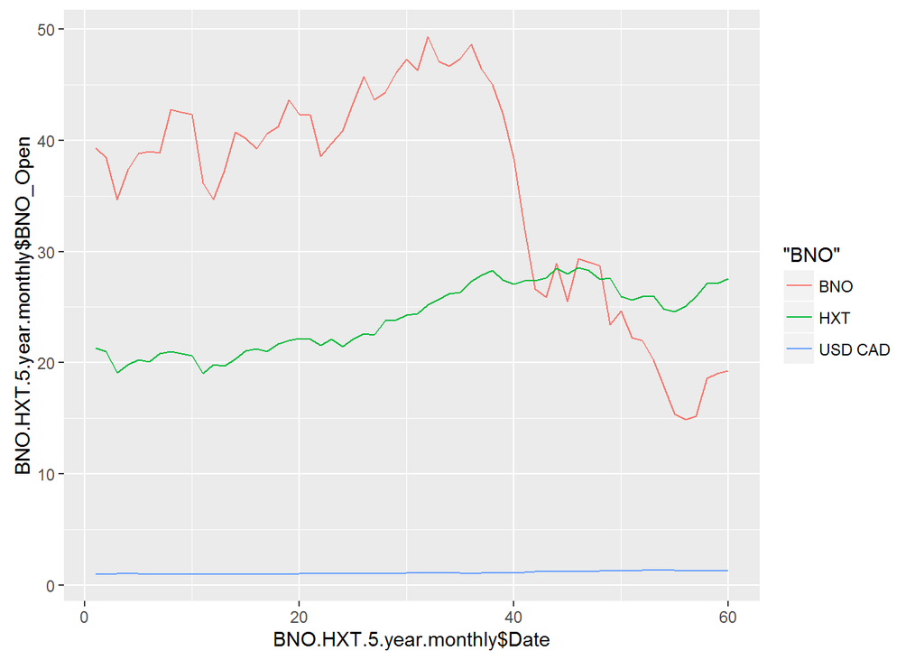

```r
Line1<-Line1+geom_line(aes(y=BNO.HXT.5.year.monthly$CAD_USD, colour="USD CAD"))
print(Line1)
```

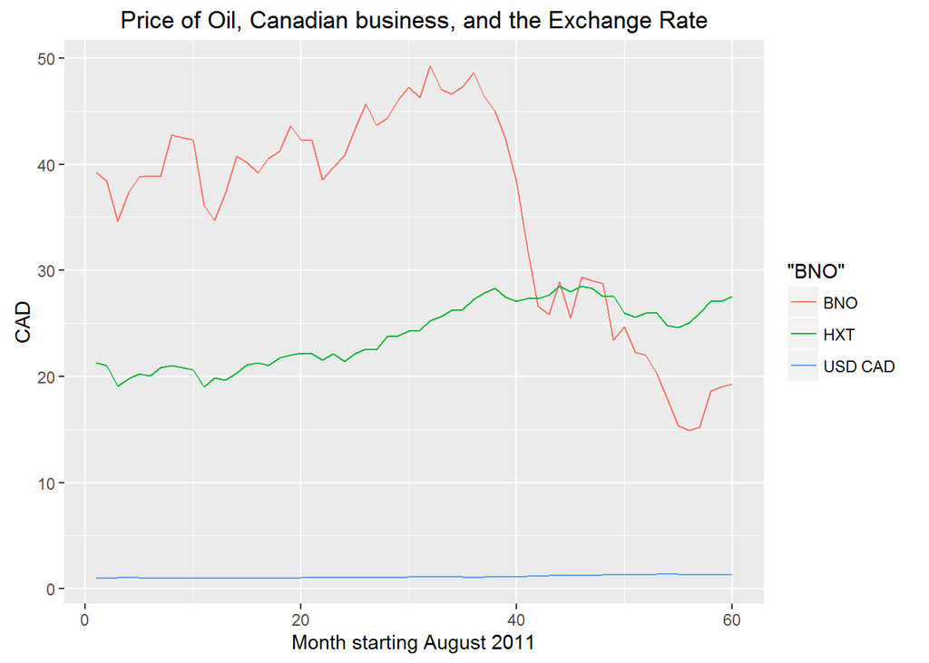

```r
Line1<-Line1+labs(title="Price of Oil, Canadian business, and the Exchange Rate", x = "Month starting August 2011", y = "CAD")
print(Line1)
```